# Influences of student data on final exam scores

Alliance of the Unshabby

2024-12-10

## Introduction

Our main purpose with this dataset is to be able to predict student performance via exam scores from the values of the other variables in the dataset. We want to be able to see what key factors in a student’s life, both at school and at home, can be correlated to higher or lower exam scores. We have some theories as to what specific factors we think will have a certain effect on scores, and we want to test those by creating models and generating plots and summaries that can showcase whether we should accept or reject the null hypothesis.

This data showcases a statistical summary of students’s performance and activities done in school as well as outside factors. It looks at factors like their attendance, sleep, level of parental guidance, distance from school to home, motivation, and many more. Some factors are objective, such as distance to school and attendance, whereas other factors, such as teacher evaluation and motivation, are more subjective. Thus this dataset does have some natural bias built into it.

As mentioned on the dataset [Kaggle page](https://www.kaggle.com/datasets/lainguyn123/student-performance-factors): “The”Student Performance Factors” dataset is a synthetic dataset generated for educational and analytical purposes. The data is not sourced from any real-world institutions but is created to simulate realistic scenarios for analyzing student performance factors”. Simply, this dataset is made for analysis and simulation. We will assume the data shown is very plausible to happen in real life so that our observations and tests are as authentic as possible.

List of variables: `Exam_Score` from the data of `Hours_Studied`, `Attendance`, `Parental_Involvement`, `Access_to_Resources`, `Extracurricular_Activities`, `Sleep_Hours`, `Previous_Scores`, `Motivation_Level`, `Internet_Access`, `Tutoring_Sessions`, `Family_Income`, `Teacher_Quality`, `School_Type`, `Peer_Influence`, `Physical_Activity`, `Learning_Disabilities`, `Parental_Education_Level`, `Distance_from_Home`, `Gender`, and finally `Exam_Score`.

The variables are the factors of interest that may be affecting exam scores. These range from actions done during school, like tutoring sessions, teacher quality, and previous scores, to factors involving the students home lives, like parental guidance and access to the internet and other resources. They help us gauge a student’s current academic situation and their mood in regards to schoolwork and how factors outside of the classroom are impacting them.

We found this dataset interesting to study because, around finals time, the results were notable to compare to our own lives and study habits. As students, we had subjective reasoning for how we studied or approached classes in ways we thought would help us perform better on final exams. It was also interesting because the dataset included many factors regarding a student’s mental mood, which is often overlooked in discussions about what might affect exam scores.

To figure out what variables or combinations of variables had significant correlations with exam scores, we used a variety of methods and models to minimize bias. We first set each variable to a factor variable, started with an initial model using ten of the variables, and then evaluated the $R^2$ values to decide on the best paths forward.

We used tests like the Breusch-Pagan test and created plots, such as fitted vs residual and Q-Q plots, to accept or reject null hypotheses for certain models we believed would significantly impact final exam scores. The purpose of creating a model was not to look at one variable and claim it was the sole reason for a student’s success or struggles on exams. A student’s life is complex, and the beauty of this dataset was that it covered so many different factors of the student experience. Thus, we created a complex model involving multiple variables to better reflect all these factors and to test multiple hypotheses.

We also ensured that any model we used was suitable for making assumptions based on its results. We used RMSE and LOOCV RMSE tests to verify that the model was not only appropriate for its given data but also capable of handling additional data and providing accurate results. Testing for outliers was also crucial. While their presence in a dataset is not inherently bad, we identified and analyzed them to adjust our model accordingly.

```r
# Utility Functions used in this Report
format_decimal = function(x, k) trimws(format(round(x, k), nsmall=k))
```

## Methods

### Data Preparation

```r
file_path <- "StudentPerformanceFactors.csv"

students_data <- read.csv(file_path)

head(students_data$Exam_Score)
```

```
## [1] 67 61 74 71 70 71
```

```r
# Remove empty observations
students_data = subset(students_data, students_data$Teacher_Quality != "")
students_data = subset(students_data, students_data$Parental_Education_Level != "")
students_data = subset(students_data, students_data$Distance_from_Home != "")
students_data = na.omit(students_data)

# Change Parental_Involvement to a factor variable
students_data$Parental_Involvement = as.factor(students_data$Parental_Involvement)
levels(students_data$Parental_Involvement)
```

```
## [1] "High"   "Low"    "Medium"
```

```r
# Change Access_to_Resources to a factor variable
students_data$Access_to_Resources = as.factor(students_data$Access_to_Resources)
levels(students_data$Access_to_Resources)
```

```
## [1] "High"   "Low"    "Medium"
```

```r
# Change Extracurricular_Activities to a factor variable
students_data$Extracurricular_Activities = as.factor(students_data$Extracurricular_Activities)
levels(students_data$Extracurricular_Activities)
```

```
## [1] "No"  "Yes"
```

```r
# Change Motivation_Level to a factor variable
students_data$Motivation_Level = as.factor(students_data$Motivation_Level)
levels(students_data$Motivation_Level)
```

```
## [1] "High"   "Low"    "Medium"
```

```r
# Change Internet_Access to a factor variable
students_data$Internet_Access = as.factor(students_data$Internet_Access)
levels(students_data$Internet_Access)
```

```
## [1] "No"  "Yes"
```

```r
# Change Family_Income to a factor variable
students_data$Family_Income = as.factor(students_data$Family_Income)
levels(students_data$Family_Income)
```

```
## [1] "High"   "Low"    "Medium"
```

```r
# Change Teacher_Quality to a factor variable
students_data$Teacher_Quality = as.factor(students_data$Teacher_Quality)
levels(students_data$Teacher_Quality)
```

```
## [1] "High"   "Low"    "Medium"
```

```r
# Change School_Type to a factor variable
students_data$School_Type = as.factor(students_data$School_Type)
levels(students_data$School_Type)
```

```
## [1] "Private" "Public"
```

```r
# Change Peer_Influence to a factor variable
students_data$Peer_Influence = as.factor(students_data$Peer_Influence)
levels(students_data$Peer_Influence)
```

```
## [1] "Negative" "Neutral"  "Positive"
```

```r
# Change Learning_Disabilities to a factor variable
students_data$Learning_Disabilities = as.factor(students_data$Learning_Disabilities)
levels(students_data$Learning_Disabilities)
```

```
## [1] "No"  "Yes"
```

```r
# Change Parental_Education_Level to a factor variable
students_data$Parental_Education_Level = as.factor(students_data$Parental_Education_Level)
levels(students_data$Parental_Education_Level)
```

```
## [1] "College"      "High School"  "Postgraduate"
```

```r
# Change Distance_from_Home to a factor variable
students_data$Distance_from_Home = as.factor(students_data$Distance_from_Home)
levels(students_data$Distance_from_Home)
```

```
## [1] "Far"      "Moderate" "Near"
```

```r
# Change Gender to a factor variable
students_data$Gender = as.factor(students_data$Gender)
levels(students_data$Gender)
```

```
## [1] "Female" "Male"
```

```r
# Check the size of the prepared dataset
length(students_data$Exam_Score)
```

```
## [1] 6378
```

### Modeling Process

We will use 10 of the predictors in the dataset to build a model. By adjusting the initial model, we will try to get a good model that can accurately predict the student’s `Exam_Score` from the data of `Hours_Studied`, `Attendance`, `Parental_Involvement`, `Extracurricular_Activities`, `Sleep_Hours`, `Previous_Scores`, `Tutoring_Sessions`, `Physical_Activity`, `Parental_Education_Level`, and `Gender`.

```r
# Construct an initial model. We choose a additive model of 10 predictors by multiple linear regression.
initial_model = lm(Exam_Score ~ Hours_Studied + Attendance + Parental_Involvement +
                   Extracurricular_Activities + Sleep_Hours + Previous_Scores +
                   Tutoring_Sessions + Physical_Activity + Parental_Education_Level + Gender,
                   data = students_data)

# Check collinearity
faraway::vif(initial_model)
```

```
##                        Hours_Studied                           Attendance
##                             1.001299                             1.002319
##              Parental_InvolvementLow           Parental_InvolvementMedium
##                             1.360566                             1.360817
##        Extracurricular_ActivitiesYes                          Sleep_Hours
##                             1.001141                             1.001575
##                      Previous_Scores                    Tutoring_Sessions
##                             1.002641                             1.001026
##                    Physical_Activity  Parental_Education_LevelHigh School
##                             1.001981                             1.329495
## Parental_Education_LevelPostgraduate                           GenderMale
##                             1.328258                             1.001029
```

```r
# Check R^2
summary(initial_model)$r.squared
```

```
## [1] 0.6377763
```

From the output, we can see that the variance inflation factor of all the predictors are lower than 5, so we may not worry about collinearity.

```r
# Then, we do a AIC backward search to select a model
selected_model = step(initial_model, direction = "backward", trace = 0)

# Check the selected model
selected_model
```

```
##
## Call:
## lm(formula = Exam_Score ~ Hours_Studied + Attendance + Parental_Involvement +
##     Extracurricular_Activities + Previous_Scores + Tutoring_Sessions +
##     Physical_Activity + Parental_Education_Level, data = students_data)
##
## Coefficients:
##                          (Intercept)                         Hours_Studied
##                             41.37333                               0.29379
##                           Attendance               Parental_InvolvementLow
##                              0.19782                              -1.95455
##           Parental_InvolvementMedium         Extracurricular_ActivitiesYes
##                             -1.03243                               0.56004
##                      Previous_Scores                     Tutoring_Sessions
##                              0.04937                               0.49307
##                    Physical_Activity   Parental_Education_LevelHigh School
##                              0.15227                              -0.46710
## Parental_Education_LevelPostgraduate
##                              0.51507
```

```r
# Check collinearity
faraway::vif(initial_model)
```

```
##                        Hours_Studied                           Attendance
##                             1.001299                             1.002319
##              Parental_InvolvementLow           Parental_InvolvementMedium
##                             1.360566                             1.360817
##        Extracurricular_ActivitiesYes                          Sleep_Hours
##                             1.001141                             1.001575
##                      Previous_Scores                    Tutoring_Sessions
##                             1.002641                             1.001026
##                    Physical_Activity  Parental_Education_LevelHigh School
##                             1.001981                             1.329495
## Parental_Education_LevelPostgraduate                           GenderMale
##                             1.328258                             1.001029
```

From the output of vif, we can see that we do not need to worry about collinearity for the selected model. Then, we want to check the model assumptions.

```r
# Construct a function for plotting
assumptions_plots = function(model, pcol = "grey", lcol = "dodgerblue") {
  par(mfrow = c(1, 2))
    plot(fitted(model), resid(model), col = pcol, pch = 20,
     xlab = "Fitted", ylab = "Residuals", main = "Fitted Versus Residuals Plot")
    abline(h = 0, col = lcol, lwd = 2)
    qqnorm(resid(model), main = "Normal Q-Q Plot", col = pcol)
    qqline(resid(model), col = lcol, lwd = 2)
}
```

```r
# Construct a function for calculating the LOOCV RMSE
calc_loocv_rmse = function(model) {
  sqrt(mean((resid(model) / (1 - hatvalues(model))) ^ 2))
}
```

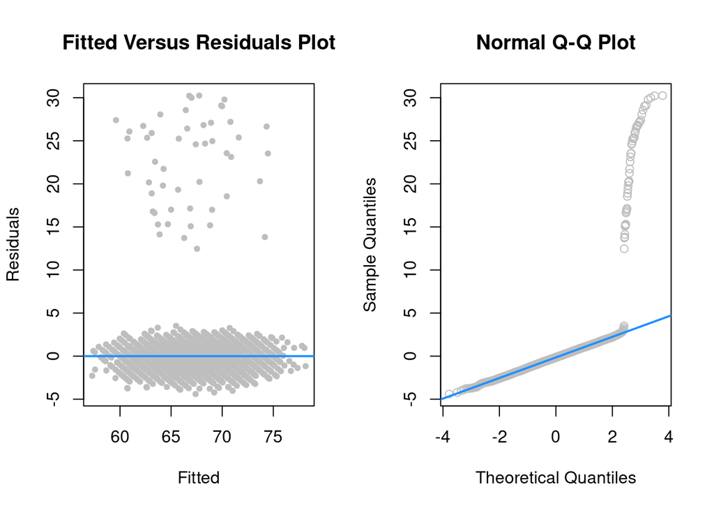

```r
library(lmtest)
# Plot the Fitted vs Residual plot and Normal Q-Q plot
assumptions_plots(selected_model)
```

```r
# Do a Breusch-Pagan Test
bptest(selected_model)
```

```
##
##  studentized Breusch-Pagan test
##
## data:  selected_model
## BP = 7.5716, df = 10, p-value = 0.6706
```

For both of the plots, we can clearly see that there are some outliers in this model, which might be influential. Thus, we may need to do some adjustments for the selected model. From the Fitted Versus Residual Plot and the Breusch-Pagan Test, we can see that the mean of the residuals is roughly 0 and the spread of the residuals is roughly the same at most fitted values and the p-value for the Breusch-Pagan Test is really large, which means the linearity and constant variance assumptions are valid. However, from the Normal Q-Q plot, we can see that the points do not do not closely follow a straight line, which suggests that the normal distribution assumption is not valid.

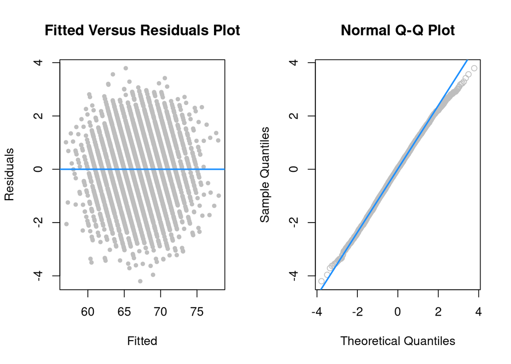

```r
# Calculate the cooks distance of the selected model
cd_selected_model = cooks.distance(selected_model)

# Identify influential rows with Cook's Distance > 4/n
influential_indices = which(cd_selected_model > 4 / length(cd_selected_model))

# Remove those rows from the original dataset
students_data_cleaned = students_data[-influential_indices, ]

# Build a fixed model that excludes all the influential data (cooks distance > 4/n)
fix_model = lm(Exam_Score ~ Hours_Studied + Attendance + Parental_Involvement +
    Extracurricular_Activities + Previous_Scores + Tutoring_Sessions +
    Physical_Activity + Parental_Education_Level,
    data = students_data_cleaned)

# Plot the Fitted vs Residual plot and Normal Q-Q plot
assumptions_plots(fix_model)
```

```r
# Do a Breusch-Pagan Test
bptest(fix_model)
```

```
##
##  studentized Breusch-Pagan test
##
## data:  fix_model
## BP = 24.844, df = 10, p-value = 0.005649
```

The Normal Q-Q plot is much better and clearly shows that the majority of the points closely follow a straight line, indicating that the normal distribution assumption is correct. The Fitted Versus Residual Plot may look like that mean of the residuals is approximately 0 and the spread of the residuals is roughly the same at most fitted values. However, the Breusch-Pagan test gives a pretty low p-value: 0.0056493, which implies that the constant variance assumption is not valid for the model after adjustments. Therefore, we need to do some transformations.

```r
# Do some Predictor transformations
trans_model = lm(Exam_Score ~ Hours_Studied + I(Hours_Studied ^ 2) + log(Attendance) + Parental_Involvement +
    Extracurricular_Activities + log(Previous_Scores) + sqrt(Tutoring_Sessions) +
    Physical_Activity + I(Physical_Activity ^ 2) + Parental_Education_Level,
    data = students_data_cleaned)

# Do a Breusch-Pagan Test
bptest(trans_model)
```

```
##
##  studentized Breusch-Pagan test
##
## data:  trans_model
## BP = 21.822, df = 12, p-value = 0.03956
```

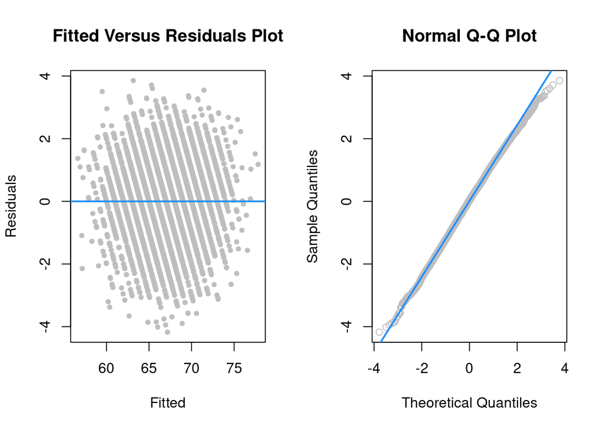

```r
# Plot the Fitted vs Residual plot and Normal Q-Q plot
assumptions_plots(trans_model)
```

After the transformation, we find that the p-value of the Breusch-Pagan test is 0.0396, which means that the test rejects the null hypothesis of constant variance for $\alpha = 0.05$, indicating that the constant variance assumption is not valid. However, from the Fitted Versus Residual Plot, we can see that the mean of the residuals is approximately 0 and the spread of the residuals is roughly the same at most fitted values, which indicates that we are close to meeting the assumption of constant variance. Moreover, the Normal Q-Q plot looks really good as the majority of the points closely follow a straight line, indicating that the normal distribution assumption is almost correct. Therefore, while this transformed model shows promising results and we are on the right track, further transformations, such as using Box-Cox, will be performed to address the remaining issues.

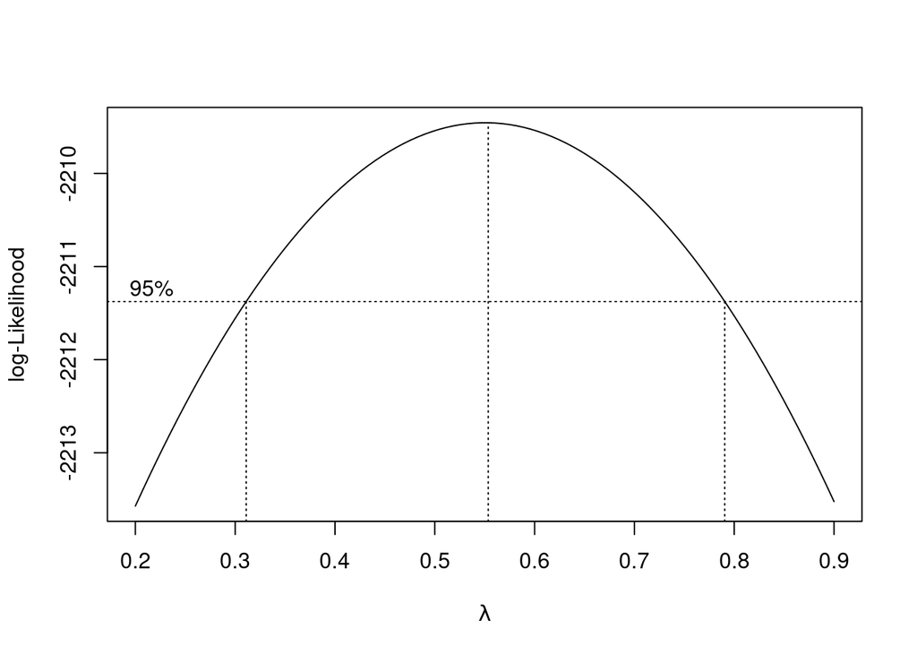

```r
library(MASS)
boxcox(trans_model, lambda = seq(0.2, 0.9, 0.01))
```

The **Box-Cox plot** demonstrates that a response transformation could significantly enhance the model’s fit. The estimated value of $\lambda$ is approximately **0.6**, which falls within the 95% confidence interval of $0.3$ to $0.8$. After evaluating several values within this interval, $\lambda = 0.6$ was selected because it yielded the largest Breusch-Pagan test p-value, indicating the best stabilization of variance. This transformation is expected to address heteroscedasticity and improve adherence to the model’s assumptions.

```r
# Add Box-Cox transformation to Response
trans_model_cox = lm(
  (((Exam_Score ^ 0.6) - 1) / 0.6) ~ Hours_Studied + I(Hours_Studied ^ 2) + log(Attendance) + Parental_Involvement + Extracurricular_Activities + log(Previous_Scores) + sqrt(Tutoring_Sessions) + Physical_Activity + I(Physical_Activity ^ 2) + Parental_Education_Level,
  data = students_data_cleaned
)

# Do a Breusch-Pagan Test
bptest(trans_model_cox)
```

```
##
##  studentized Breusch-Pagan test
##
## data:  trans_model_cox
## BP = 18.643, df = 12, p-value = 0.09753
```

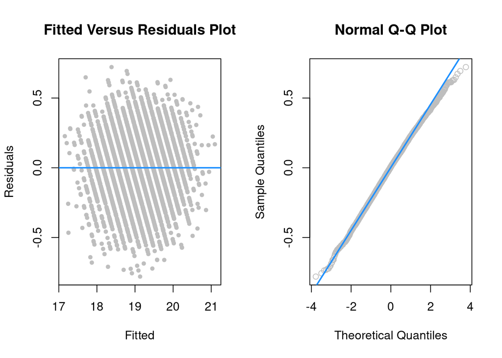

```r
# Plot the Fitted vs Residual plot and Normal Q-Q plot
assumptions_plots(trans_model_cox)
```

After applying the Box-Cox transformation with $\lambda = 0.6$, the Breusch-Pagan test yielded a p-value of 0.0975, indicating that the test fails to reject the null hypothesis of constant variance. This confirms that the constant variance assumption is now valid. The **Fitted Versus Residual Plot** shows that the residuals have a mean approximately equal to 0, with a consistent spread across the fitted values, supporting the linearity and constant variance assumptions. Additionally, the **Normal Q-Q plot** demonstrates that the residuals closely follow the diagonal line, confirming that the normality assumption is satisfied. These results validate the final model with the Box-Cox transformation, making it suitable for interpretation and inference.

## Results

### Final Model

The final model selected for predicting exam scores incorporates key predictors, including transformed terms for Hours_Studied, Attendance, Previous_Scores, and Physical_Activity, as well as categorical variables like Parental_Involvement and Parental_Education_Level. The model equation is as follows:
$$\begin{aligned}
\frac{\text{Exam_Score}^{0.6} - 1}{0.6} = & \ \beta_0 + \beta_1
\cdot \text{Hours_Studied} + \beta_2 \cdot \text{Hours_Studied}^2 +
\beta_3 \cdot \log(\text{Attendance}) \\
& + \beta_4 \cdot \text{Parental_Involvement}_{\text{Low}} + \beta_5
\cdot \text{Parental_Involvement}_{\text{Medium}} + \beta_6 \cdot
\text{Extracurricular_Activities} \\
& + \beta_7 \cdot \log(\text{Previous_Scores}) + \beta_8 \cdot
\sqrt{\text{Tutoring_Sessions}} + \beta_9 \cdot \text{Physical_Activity}
\\
& + \beta_{10} \cdot \text{Physical_Activity}^2 + \beta_{11} \cdot
\text{Parental_Education_Level}_{\text{High_School}} \\
& + \beta_{12} \cdot
\text{Parental_Education_Level}_{\text{Postgraduate}} + \epsilon
\end{aligned}$$

### Model Performance

```r
# RMSE
rmse = sqrt(mean(resid(trans_model_cox)^2))
cat("Root Mean Squared Error (RMSE):", rmse, "\n")
```

```
## Root Mean Squared Error (RMSE): 0.2221724
```

```r
# LOOCV RMSE
loocv_rmse = calc_loocv_rmse(trans_model_cox)
cat("Leave-One-Out Cross-Validation RMSE (LOOCV RMSE):", loocv_rmse, "\n")
```

```
## Leave-One-Out Cross-Validation RMSE (LOOCV RMSE): 0.222632
```

```r
# Extract adjusted R^2 from model summary
adjusted_r2 = summary(trans_model_cox)$adj.r.squared
cat("Adjusted R^2:", adjusted_r2, "\n")
```

```
## Adjusted R^2: 0.8731002
```

The final model demonstrates strong predictive capability with an adjusted $R^2$ of 0.8731, indicating that it explains the majority of the variability in the exam scores. Additionally, the Root Mean Squared Error (RMSE) of the model is 0.2222, and the Leave-One-Out Cross-Validation RMSE (LOOCV RMSE) is 0.2226. The similarity between the RMSE and LOOCV RMSE models confirms that the model generalizes well to unseen data, making it suitable for prediction tasks.

### Predicted vs Actual Plot

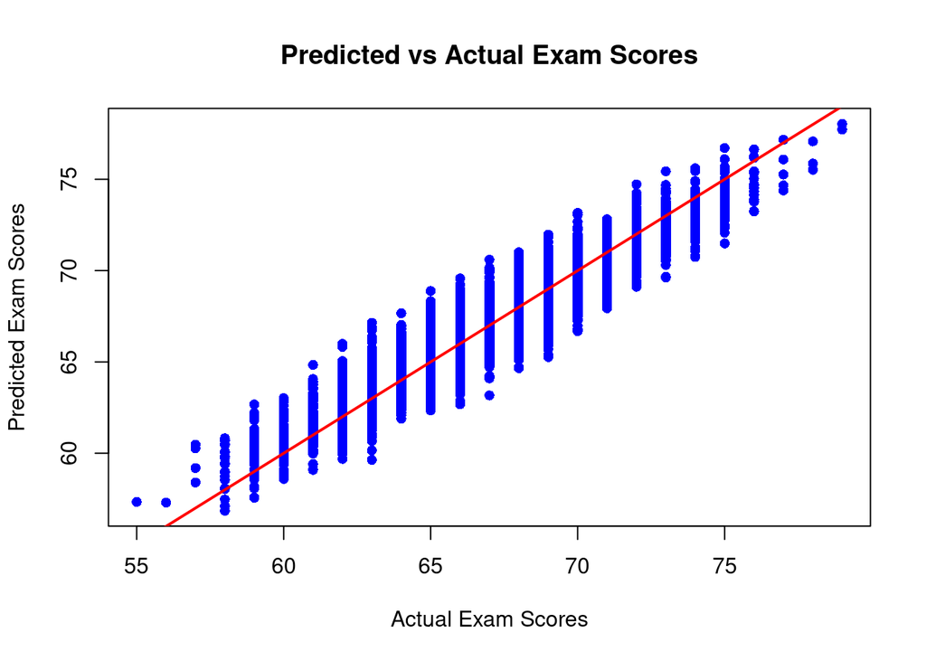

```r
# Generate predicted values
predicted_values = predict(trans_model_cox)

# Reverse the Box-Cox transformation
original_scale_predictions = (predicted_values * 0.6 + 1)^(1 / 0.6)

# Create the plot
plot(students_data_cleaned$Exam_Score, original_scale_predictions,
     xlab = "Actual Exam Scores",
     ylab = "Predicted Exam Scores",
     main = "Predicted vs Actual Exam Scores",
     pch = 16, col = "blue")
abline(0, 1, col = "red", lwd = 2)
```

The points in the **Predicted vs Actual Exam Scores** plot generally cluster along the red 45-degree line, indicating a strong agreement between the model’s predictions and the actual exam scores. This suggests that the model captures the underlying relationship in the data effectively.

### Residuals vs Fitted plot

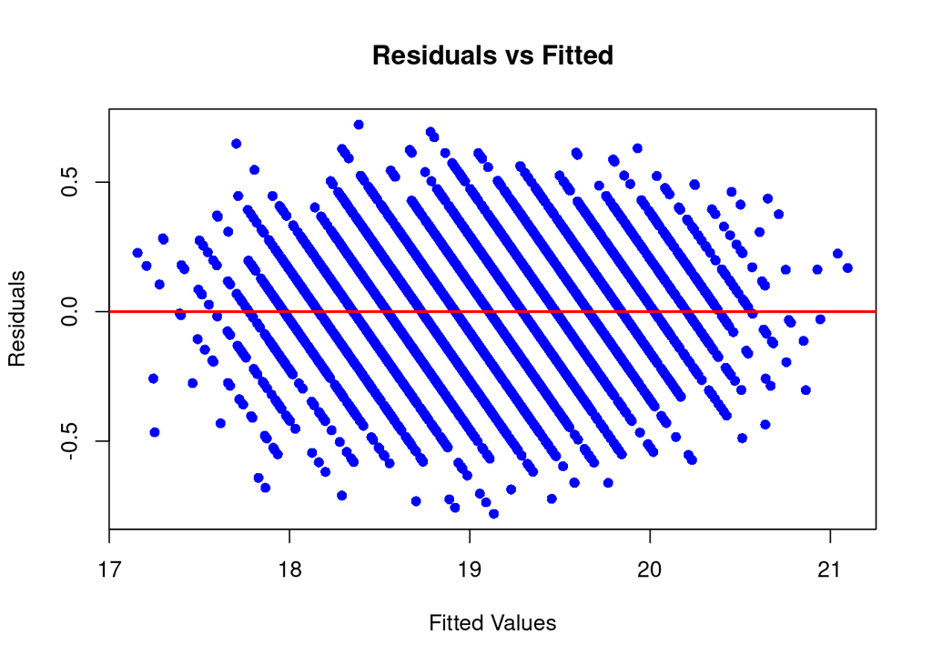

```r
# Residual plot
plot(fitted(trans_model_cox), resid(trans_model_cox),
     xlab = "Fitted Values",
     ylab = "Residuals",
     main = "Residuals vs Fitted",
     pch = 16, col = "blue")
abline(h = 0, col = "red", lwd = 2) # Add a horizontal line at 0
```

The **Residuals vs Fitted plot** indicates that the residuals are evenly distributed around zero, with no discernible patterns or systematic bias. This suggests that the model assumptions of linearity and independence are valid. While there is a slight decrease in variance at the extremes, this is likely due to the smaller number of data points at very low and very high exam scores, which are less common in the dataset. Overall, the model demonstrates good reliability across the range of predicted values.

### Breusch-Pagan Test

```r
# Perform the Breusch-Pagan test
library(lmtest)
bp_test = bptest(trans_model_cox)
bp_test
```

```
##
##  studentized Breusch-Pagan test
##
## data:  trans_model_cox
## BP = 18.643, df = 12, p-value = 0.09753
```

The **Breusch-Pagan Test** was conducted to statistically assess heteroscedasticity. The test yielded a p-value of 0.0975, which suggests that the residuals do exhibit constant variance. This aligns with the visual inspection of the residuals vs. fitted plot, further validating the reliability of the model.

### Q-Q Plot

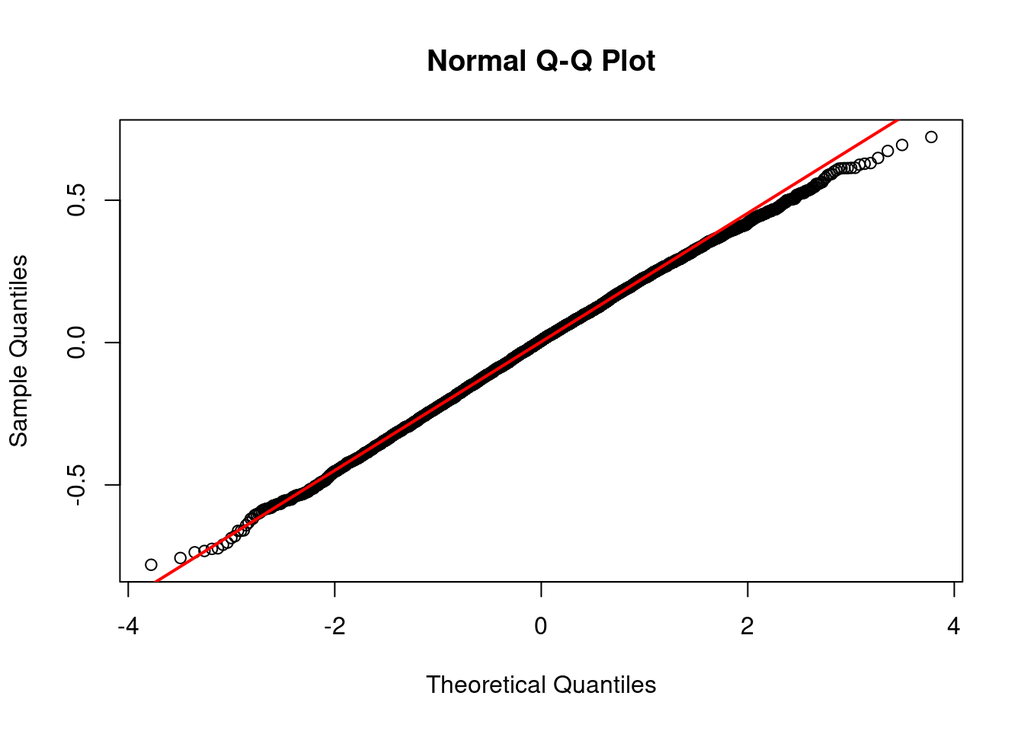

```r
# Generate Q-Q plot for the residuals
qqnorm(resid(trans_model_cox), main = "Normal Q-Q Plot")
qqline(resid(trans_model_cox), col = "red", lwd = 2)
```

The **Q-Q plot** shows that most residuals closely follow the diagonal line, indicating that the residuals are approximately normally distributed. However, minor deviations at the extremes suggest some potential issues with extreme observations. These deviations are not severe and likely do not significantly impact the overall conclusions drawn from the model.

### Outliers

To address potential issues with influential data points, rows with Cook’s Distance greater than $\frac{4}{n}$ were identified and removed. A total of 51 data points were excluded, representing approximately 0.8% of the dataset. This adjustment was relatively small, as it affected only a minor portion of the overall data. By removing these points, we improved the model’s robustness without significantly altering the dataset’s structure or underlying patterns.

## Appendix

### Group Members

- Anshul Kaushik
- Desmond Fung
- Jon Green
- Kangyi Jiang